# Milestone Report for JHU

xuanru shen

5/6/2017

## Abstract

This report is based on the John Hopkins capstone project instruction. It is a sub report in the second week called Milestone Report. We here apply the data we get from website containing blogs, news and twitter text data. Use the text mining method to get a n-gram word prediction idea and apply exploratory data analysis for those texts.

## Introduction

### - technique applied

Text Mining and word cloud, some knowlegede of n-gram word prediction, markov-chain if needed. Basic exploratory data analysis is most essential.I use tm, wordcould and ggplot2 package for this report.

## Loading Data

Basic Data Info

```r
setwd("~/Downloads/Course")
input_file<-file("en_US/en_US.blogs.txt",open = 'r')
linn_USblogs <-readLines(input_file); close(input_file)
# I tried colSums in this file but since the file is tsoo large,it cannot fun the function. Here just use the system2 to get the character/word/line count.
```

```r
blogsWords <- sum(sapply(gregexpr("\\S+", linn_USblogs), length))
blogsleng<-length(linn_USblogs);
blogsize <- object.size(linn_USblogs)/1024/1024 # MB as unit

newSubset<- sample(linn_USblogs, size=length(linn_USblogs)*.12, replace=FALSE)
USblogs<- Corpus(VectorSource(newSubset))
```

Word count is 37334147, the number of rows (length of the file) is 899288, the size of the file is 248.4934998 MB

I use the subset for the further exploring. One reason is for saving time, but the trade off is the accuracy for further model prediction.

## Preprocessing

```r
# Since it's text mining, we ignore numbers, punctuation and special characters and while space at this stage
USblogs <- tm_map(USblogs, removeNumbers)
USblogs <- tm_map(USblogs, removePunctuation)
USblogs <- tm_map(USblogs, removeWords,stopwords("english"))
USblogs <- tm_map(USblogs, stripWhitespace)
# USblogs <- tm_map(USblogs, stemDocument)
USblogs_dtm <- DocumentTermMatrix(USblogs)
```

## Exploratory Data Analysis & Visualization

```r
findFreqTerms(USblogs_dtm,lowfreq=20000)
dtm1 <- removeSparseTerms(USblogs_dtm, 0.99)
# findAssocs(USblogs_dtm,'love',0.15)
```

[output not shown]

After basic cleaning for the dataset, we then apply frequency analysis to it. We want to know the frequency of the words. Then applies the histogram to show the outcome.

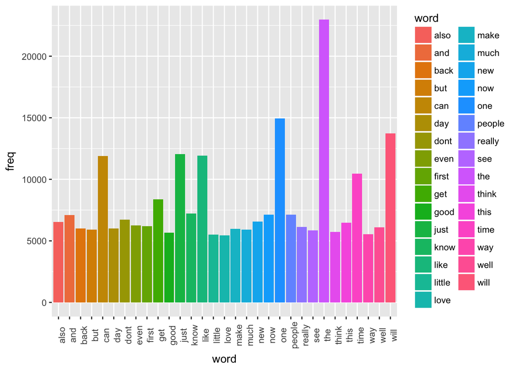

```r
freq <- sort(colSums(as.matrix(dtm1)),decreasing = TRUE)
word_freq <- data.frame(word = names(freq),freq=freq)
p <- ggplot(subset(word_freq,freq>5000),aes(word,freq))
p <- p+geom_bar(stat = "identity",aes(fill = word)) +
  theme(axis.text.x = element_text(angle=90))
p
```

Here we use the word Cloud to display the result for ngram, while n= 1

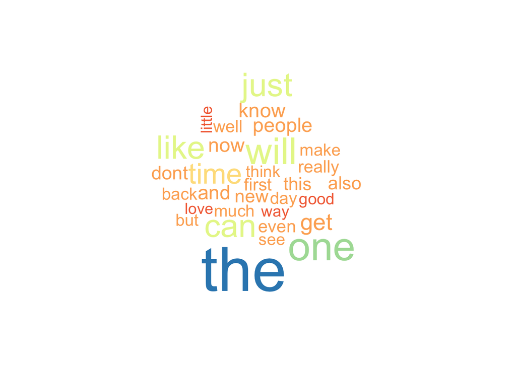

```r
wordcloud(names(freq), freq, min.freq=5000, scale=c(5, .1), colors=brewer.pal(8, "Spectral"))
```

## Further Work

From the plots, we can find many words that have the higher frequency that doesn’t have too much real meaning, like one, the, can etc. After getting this idea, we then would use the freqency to help predict the n-gram algorithm. We would increase the n to get large warehouse for the exploring. I will use NGramTokenizer function for that. It is well-wrriten function in R.

The n=2 and 3 are in my code but since it occupies too many space, I didn’t show them here. I will also consider using other packages or functions to optimize using space and time consuming issue.

The Shiny App for the prediction would be giving a short text(no matter how many words it has, the app would give the words coming next and showing the probability of it appearance.